# Bivariate Regression and OLS

EC 325: Econometrics

Prof. Caraher

Colby College

Feb 26, 2026

# From RCTs to Regression

## Where We’ve Been

- In Unit 3, we learned that **Randomized Control Trials** provide the gold standard for causal inference
- Random assignment eliminates selection bias: the simple difference in means equals the causal effect
- But most economic questions **cannot** be answered with experiments
- We typically work with **observational data** where treatment is not randomly assigned

## Where We’re Going

- Today: **Ordinary Least Squares (OLS)** regression – the workhorse tool of econometrics
- We focus on the **bivariate** case (one independent variable) to build intuition

**The Big Question**

When can we interpret a regression coefficient as a **causal effect** vs. a mere **correlation**?

# Modeling Relationships Between Variables

## What Do We Mean by “Relationship”?

- Suppose we have two variables, $y$ and $x$
- We want to study “how $x$ is related to $y$”
- We need a precise, mathematical way to do this
- The most natural approach: what is the **average** value of $y$ for each different value of $x$?

## Conditional Expectations

- This idea is called the **conditional expectation**

$$E[Y | X = x]$$

- “If we knew that $X$ took on some specific value $x$, what would we expect $Y$ to be, **on average**?”
- The conditional expectation is the central quantity we want to model and estimate

## Example: Education and Wages

- $X$ = education level (HS degree, College degree, Professional degree)
- $Y$ = hourly wage
- For each education level, compute the average wage among people in that group

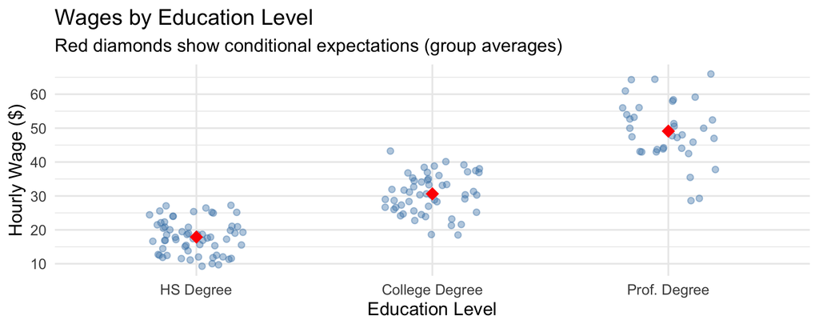

## What Do We See?

- The **red diamonds** show the conditional expectations: $E[Y|X=\text{HS}]$, $E[Y|X=\text{College}]$, $E[Y|X=\text{Prof}]$
- These averages tell us how wages **change** as education increases
- This is precisely what we want to estimate!

# Visualizing Relationships: Scatter Plots

## Why Scatter Plots?

- When both $x$ and $y$ are **continuous**, a scatter plot is the best way to visualize their relationship
- Each point represents one observation: its $x$ value and its $y$ value
- Scatter plots help us:
  - See the **direction** of a relationship (positive or negative)
  - Identify **outliers** or unusual patterns
  - Judge whether a **linear** model is appropriate

## Introduction to `ggplot2`

- We’ll use the `ggplot2` package (part of the `tidyverse`) for all our visualizations
- `ggplot2` builds plots **layer by layer** – you start with data, then add visual elements on top:
1. **Start with data:** `ggplot(data = your_data)` – creates an empty canvas
2. **Add a geometry:** `+ geom_point(...)` for scatter plots, `+ geom_histogram(...)` for histograms, etc.
3. **Map variables to aesthetics:** inside `aes()`, tell R which columns go on each axis (and optionally `color`, `size`, `shape`, etc.)
4. **Polish:** add labels with `labs()` and a clean theme with `theme_minimal()`

**Want More?**

The Unit 2 lecture notes cover `ggplot2` in much more detail, including histograms, bar charts, and more customization options. Refer back to those as needed!

## Building a Scatter Plot

**🖥️ Try it yourself!**

- Let’s build a scatter plot step by step. Start with data and add points using `geom_point()`:

```r
library(tidyverse)

ggplot(data = mtcars) +
  geom_point(aes(x = hp, y = mpg))
```

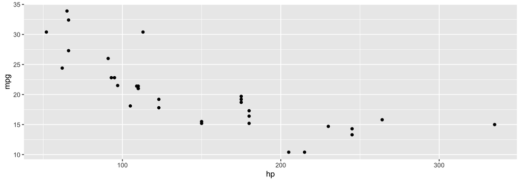

## Making Publication-Quality Plots

**🖥️ Try it yourself!**

Always add proper labels and a clean theme:

```r
ggplot(data = mtcars) +
  geom_point(aes(x = hp, y = mpg)) +
  labs(
    title = "Fuel Efficiency vs. Engine Power",
    x = "Horsepower",
    y = "Miles per Gallon",
  ) +
  theme_minimal()
```

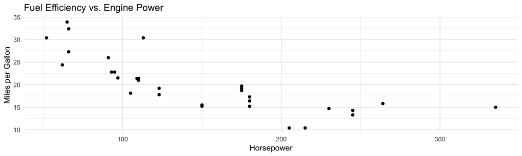

## Adding a Line of Best Fit

**🖥️ Try it yourself!**

- `geom_smooth(method = "lm")` adds a straight line that “best fits” the data

```r
ggplot(data = mtcars) +
  geom_point(aes(x = hp, y = mpg)) +
  geom_smooth(aes(x = hp, y = mpg), method = "lm", se = FALSE) +
  labs(x = "Horsepower", y = "Miles per Gallon",
       title = "MPG vs. Horsepower with Line of Best Fit") +
  theme_minimal()
```

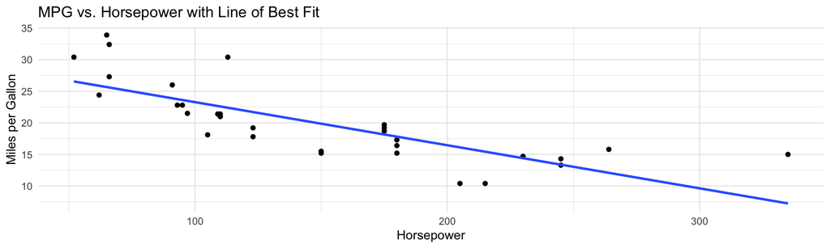

## Try It: Scatter Plot Practice

**🖥️ Your turn!**

**Create a scatter plot of `wt` (weight) vs. `mpg` (fuel efficiency). Add proper labels.**

- *Hint:* Use `geom_point()` + `labs()`

```r
ggplot(mtcars) +
  geom_point(aes(x = wt, y = mpg)) +
  labs(x = "Weight (1000 lbs)", y = "Miles per Gallon",
       title = "Heavier Cars Get Worse Fuel Efficiency") +
  theme_minimal()
```

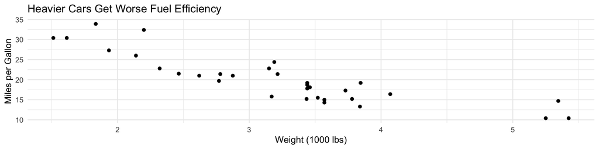

# The Population Regression Model

## Writing Down the Population Model

- We start by describing the **true relationship** in the population – even though we can’t observe it directly
- The simplest regression model relates $y$ to a single variable $x$:

$$y = \beta_0 + \beta_1 x + \mu$$

where:

- $y$ is the **dependent variable** (outcome)
- $x$ is the **independent variable** (explanatory)
- $\mu$ is the **error term** (everything else that affects $y$)
- $\beta_0$ and $\beta_1$ are **population parameters** (unknown)

## The Error Term

- The error term $\mu$ is crucial – it captures **everything** that affects $y$ other than $x$
- In a wage equation: $wage = \beta_0 + \beta_1 \cdot educ + \mu$
- $\mu$ might include:
  - Ability and motivation
  - Family connections
  - Luck
  - Work experience

## Example: Education and Wages

- With some assumptions, the regression line traces out the **conditional expectation**: $E[y|x] = \beta_0 + \beta_1 x$
- We can interpret the coefficients like we would any linear equation:
- $\beta_0$ is the value of $y$ when $x=0$
- $\beta_1$ is the **marginal effect**: a one-unit increase in $x$ changes $y$ by $\beta_1$ units, on average
- Let’s make this concrete:

$$wage = \beta_0 + \beta_1 \cdot educ + \mu$$

- $wage$ = dollars per hour
- $educ$ = years of education
- If $\beta_1 = 2.50$: each additional year of education is associated with **$2.50 higher hourly wages**, on average

# From Population to Sample

## We Can’t See the Population

- The population model $y = \beta_0 + \beta_1 x + \mu$ describes the **true** relationship present in the **population**
- But $\beta_0$ and $\beta_1$ are **unknown** – we never observe the whole population
- Instead, we use our **sample** to compute **estimates**, which we write with “hats”:
- $\hat{\beta}_0$ = our estimate of $\beta_0$
- $\hat{\beta}_1$ = our estimate of $\beta_1$

## Predicted Values and the Fitted Line

- Using our estimates, we construct the **regression line**:

$$\hat{y} = \hat{\beta}_0 + \hat{\beta}_1 x$$

- For any value of $x$, this gives us $\hat{y}$, the **predicted value** of $y$
- This is exactly what `geom_smooth(method = "lm")` draws!

## Residuals: The Prediction Errors

- Our predictions won’t be perfect. The **residual** for observation $i$ is:

$$\hat{\mu}_i = y_i - \hat{y}_i = y_i - (\hat{\beta}_0 + \hat{\beta}_1 x_i)$$

- Positive residual: we **underpredicted** (actual > predicted)
- Negative residual: we **overpredicted** (actual < predicted)

## Visualizing Residuals

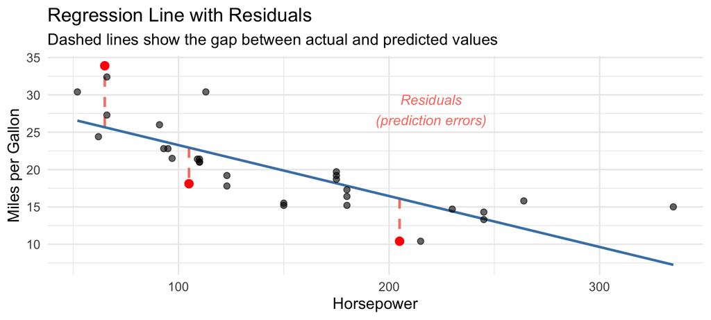

## The Goal: Minimize the Residuals

- We want to make residuals as small as possible
- Can’t just minimize $\sum \hat{\mu}_i$ – positive and negative residuals would cancel out!
- Instead, minimize the **Sum of Squared Residuals (SSR)**:

$$SSR = \sum_{i=1}^{n} \hat{\mu}_i^2 = \sum_{i=1}^{n} (y_i - \hat{\beta}_0 - \hat{\beta}_1 x_i)^2$$

- This is where the name **“Ordinary Least Squares”** comes from!

# The OLS Estimator

## The Minimization Problem

- Given $n$ observations $\{(x_i, y_i): i = 1, ..., n\}$, find $\hat{\beta}_0$ and $\hat{\beta}_1$ that minimize:

$$\min_{\hat{\beta}_0, \hat{\beta}_1} \sum_{i=1}^{n} (y_i - \hat{\beta}_0 - \hat{\beta}_1 x_i)^2$$

- This is a calculus optimization problem – take partial derivatives, set equal to zero, solve

**Full Derivation**

The step-by-step derivation using first-order conditions is in Section 4.4 of the lecture notes. We’ll skip the algebra here and focus on the **result** and its **intuition**.

## The OLS Formulas

- Solving the minimization problem gives us:

**The OLS Slope**

$$\hat{\beta}_1 = \frac{\sum_{i=1}^{n}(x_i - \bar{x})(y_i - \bar{y})}{\sum_{i=1}^{n}(x_i - \bar{x})^2} = \frac{Cov(x, y)}{Var(x)}$$

**The OLS Intercept:**

$$\hat{\beta}_0 = \bar{y} - \hat{\beta}_1 \bar{x}$$

- The regression line always passes through the point $(\bar{x}, \bar{y})$ – the “center” of the data!

## An Important Observation

- The slope can also be written as:

$$\hat{\beta}_1 = \rho_{xy} \frac{\sigma_y}{\sigma_x}$$

- Bivariate OLS is essentially a **scaled version of the correlation** between $x$ and $y$
- And as we discussed in Unit 1: **correlation does not imply causation!**
- We must be very careful about interpreting bivariate OLS results causally

## Visualizing OLS: Step 1 – The Data

Let’s build up the intuition for what OLS does, step by step.

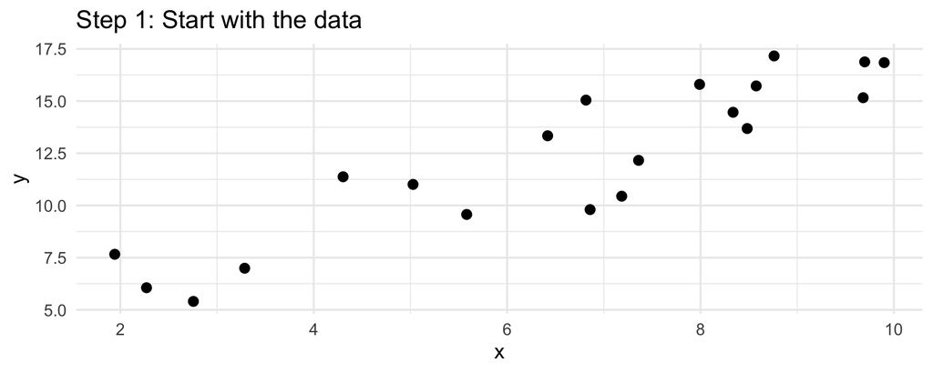

- We have 20 observations. How should we draw a line to summarize this relationship?

## Visualizing OLS: Step 2 – Try a Line

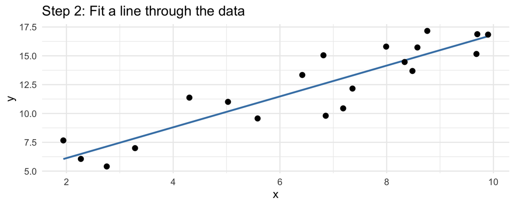

- The blue line is our “best guess” – but what makes it “best”?

## Visualizing OLS: Step 3 – One Residual

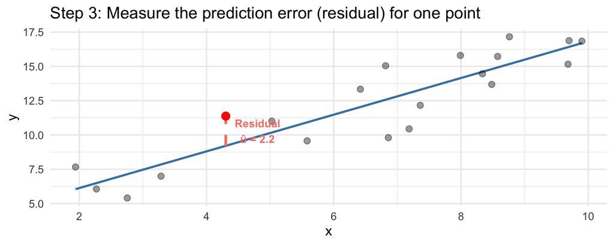

- The **residual** is the vertical distance between the point and the line

## Visualizing OLS: Step 4 – Square the Residual

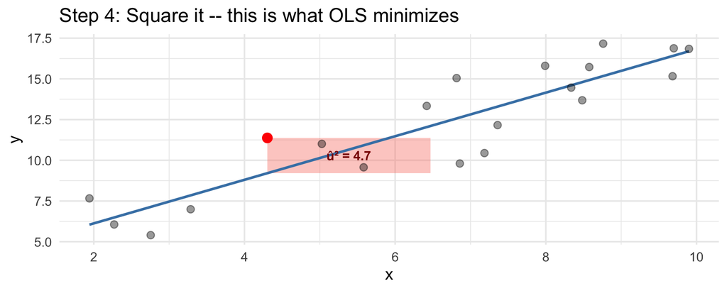

- We **square** the residual so that positive and negative errors don’t cancel

## Visualizing OLS: Step 5 – All Squared Residuals

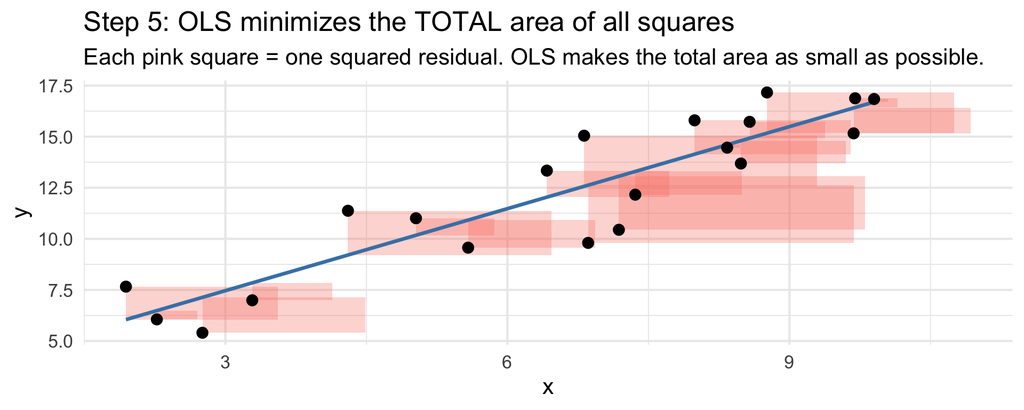

- OLS chooses $\hat{\beta}_0$ and $\hat{\beta}_1$ to make the **total pink area** as small as possible!

# Computing OLS in R

## The `lm()` Function

**🖥️ Try it yourself!**

- In R, the `lm()` function (“linear model”) performs OLS regression:

```r
# General syntax
lm(y ~ x, data = your_data)
```

- The formula `y ~ x` says: “$y$ is the dependent variable, $x$ is the independent variable”
- An **intercept** is included by default

## Example: MPG and Horsepower

**🖥️ Try it yourself!**

```r
# Estimate the regression
lm_mpg <- lm(mpg ~ hp, data = mtcars)

# View the results
summary(lm_mpg)
```

```
Call:
lm(formula = mpg ~ hp, data = mtcars)

Residuals:
    Min      1Q  Median      3Q     Max
-5.7121 -2.1122 -0.8854  1.5819  8.2360

Coefficients:
            Estimate Std. Error t value Pr(>|t|)
(Intercept) 30.09886    1.63392  18.421  < 2e-16 ***
hp          -0.06823    0.01012  -6.742 1.79e-07 ***
---
Signif. codes:  0 '***' 0.001 '**' 0.01 '*' 0.05 '.' 0.1 ' ' 1

Residual standard error: 3.863 on 30 degrees of freedom
Multiple R-squared:  0.6024,    Adjusted R-squared:  0.5892
F-statistic: 45.46 on 1 and 30 DF,  p-value: 1.788e-07
```

## Reading the Output

- $\hat{\beta}_0 = 30.10$: A car with **zero** horsepower is predicted to get 30.1 MPG (not meaningful here!)
- $\hat{\beta}_1 = -0.068$: Each additional unit of horsepower is associated with about **0.07 fewer miles per gallon**
- **R-squared = 0.60**: Horsepower explains about **60%** of the variation in MPG
- We’ll discuss standard errors and p-values in the next unit

## Visualizing the Regression Output

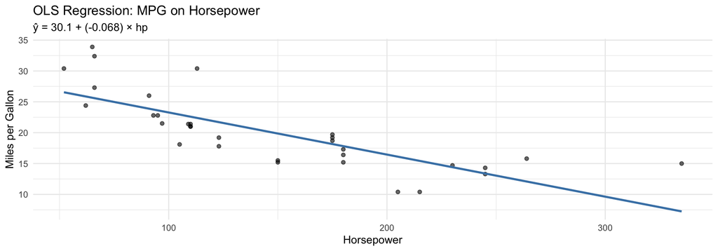

## Try It: Run Your Own Regression

**🖥️ Your turn!**

**Regress `mpg` on `wt` (weight) using the `mtcars` data. What does the slope tell you?**

- *Hint:* Use `lm(mpg ~ wt, data = mtcars)` and `summary()`

```r
lm_wt <- lm(mpg ~ wt, data = mtcars)
coef(lm_wt)
```

```
(Intercept)          wt
  37.285126   -5.344472
```

- Each additional 1,000 lbs of weight is associated with about **5.3 fewer** miles per gallon

# Goodness-of-Fit: R-Squared

## How Well Does Our Line Fit?

- **R-squared** ($R^2$) measures the fraction of variation in $y$ explained by the regression

$$R^2 = 1 - \frac{SSR}{SST}$$

where:

- $SST = \sum(y_i - \bar{y})^2$ = **total** variation in $y$
- $SSR = \sum\hat{\mu}_i^2$ = **unexplained** variation (residuals)

## R-Squared: Nearly Useless Regression

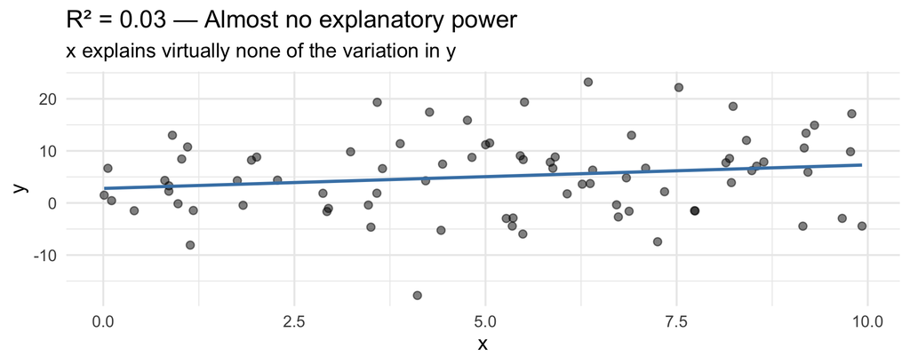

- The data is a **cloud** – knowing $x$ barely helps predict $y$

## R-Squared: Moderate Fit

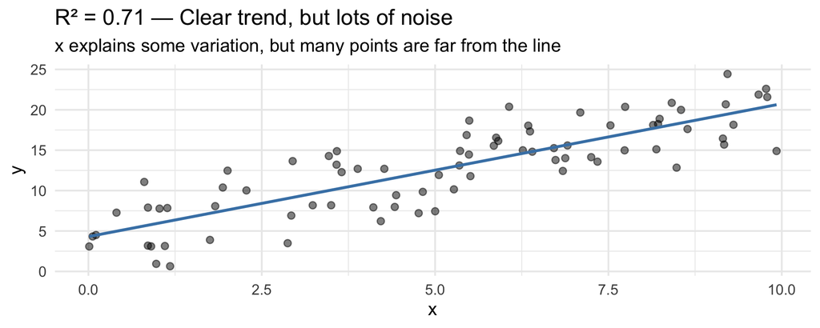

- A clear **upward trend**, but individual predictions would be imprecise

## R-Squared: Near-Perfect Fit

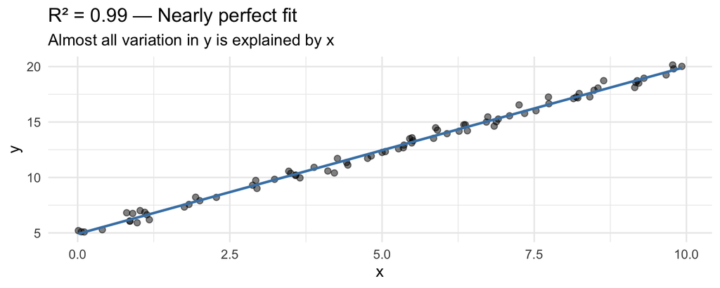

- Points hug the line tightly – $x$ explains almost everything about $y$

## Caution About R-Squared

**Don’t Over-Interpret R-Squared**

- A **high** $R^2$ does NOT mean we have a causal estimate – it just means $x$ is correlated with $y$
- A **low** $R^2$ does NOT mean our estimate is wrong or unimportant
- In cross-sectional data, $R^2$ values of 0.1 to 0.3 are common and can still represent economically meaningful relationships

# What Makes a Good Estimator?

## Can We Trust Our Estimates?

- We now know how to compute $\hat{\beta}_0$ and $\hat{\beta}_1$ – but should we trust the numbers?
- Remember: population parameters ($\beta$) are fixed, but *different samples give different estimates* ($\hat{\beta}$)
- The property we want is **unbiasedness**: on average, our estimates hit the target

**Unbiasedness**

$E[\hat{\beta}_1] = \beta_1$ — no systematic tendency to over- or under-estimate. Individual shots miss, but the **center** of all shots lands on the bullseye.

- The key question: **under what conditions** is OLS unbiased? That depends on **assumptions**.

# The Gauss-Markov Assumptions

## Assumptions 1–3: The “Mechanical” Requirements

These first three assumptions are relatively easy to check. See the lecture notes for details and examples.

| Assumption | What it says | In plain English |
| --- | --- | --- |
| 1. Linear in parameters | $y = \beta_0 + \beta_1 x + \mu$ | The model is linear in the $\beta$’s (not necessarily in $x$!) |
| 2. Random sampling | Obs. are i.i.d. draws | Our sample is representative of the population |
| 3. Variation in $x$ | $\sum(x_i - \bar{x})^2 > 0$ | $x$ isn’t the same value for everyone |

- These are usually satisfied in practice – the **hard** assumption is next

## Assumption 4: Zero Conditional Mean

$$E[\mu | x] = 0$$

**The Most Important Assumption**

The average value of all unobserved factors affecting $y$ is the **same** regardless of the value of $x$.

## What Does “Zero Conditional Mean” Mean?

- In words: $E[\mu | x] = 0$ means the **error term is unrelated to** $x$
- For *every* possible value of $x$, the average of all unobserved factors is zero
- Think of it this way: if you could gather all people with $x = 10$ and average their $\mu$ values, you’d get zero. Same for $x = 20$. Same for any $x$.

## Visualizing the Zero Conditional Mean

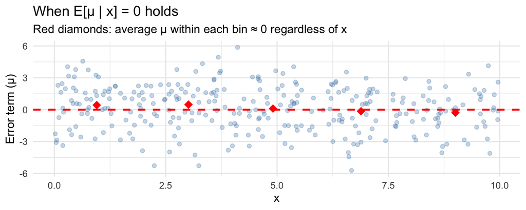

- No matter where we look along the x-axis, errors average to **zero**

## When the Zero Conditional Mean Fails

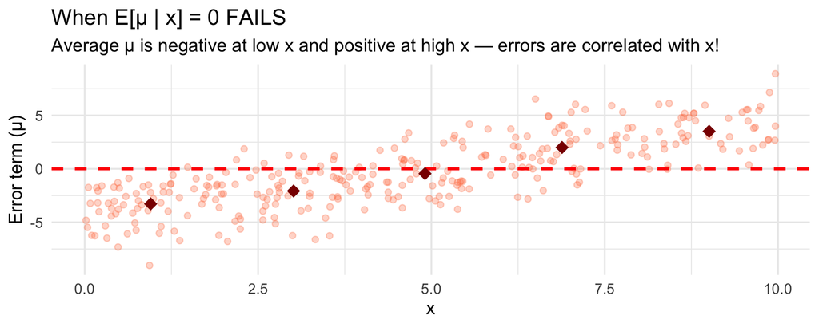

- The average error **rises** with $x$ – the error is correlated with our independent variable

## Why Does This Matter for Wages?

- Consider the wage equation: $wage = \beta_0 + \beta_1 \cdot educ + \mu$
- For $E[\mu | educ] = 0$ we need:
- Among people with 8 years of education: average $\mu$ = 0
- Among people with 12 years of education: average $\mu$ = 0
- Among people with 16 years of education: average $\mu$ = 0
- Is this plausible?
- People with more education tend to have higher **ability** (which is in $\mu$)
- So $E[\mu | educ = 16] > E[\mu | educ = 8]$ – the assumption **fails**
- This is the fundamental challenge of causal inference with observational data!

## Summary: The Four Assumptions for Unbiasedness

| Assumption | What it says |
| --- | --- |
| 1. Linear in parameters | $y = \beta_0 + \beta_1 x + \mu$ |
| 2. Random sampling | Observations are independent draws |
| 3. Variation in $x$ | $\sum(x_i - \bar{x})^2 > 0$ |
| **4. Zero conditional mean** | $E[\mu \\| x] = 0$ |

- Under these four assumptions, **OLS is unbiased**: $E[\hat{\beta}_1] = \beta_1$

# Seeing Unbiasedness in Action

## Simulating Unbiasedness

**🖥️ Try it yourself!**

Let’s prove unbiasedness to ourselves! First, create a “population” with **known** parameters:

```r
set.seed(1248)
n_pop <- 1000
pop_data <- tibble(
  x = sample(1:100, size = n_pop, replace = TRUE),
  y = 3.5 + 2.21 * x + rnorm(n_pop)
)

# The TRUE slope is 2.21
```

## Drawing Many Samples

**🖥️ Try it yourself!**

Now draw 500 random samples and estimate $\hat{\beta}_1$ each time. We use a `for()` loop to repeat the same set of steps a fixed number of times. The loop runs the code inside `{}` once for each value of `i` (from 1 to 500), so we don’t have to copy and paste the same code 500 times:

```r
set.seed(812476)
n_sims <- 500
sample_size <- 25

# Create a dataframe to store our results
sim_results <- tibble(iteration = integer(), b1_hat = numeric())

# Run the simulation
for (i in 1:n_sims) {
  samp <- slice_sample(pop_data, n = sample_size, replace = TRUE)
  b1_hat <- coef(lm(y ~ x, data = samp))[2]
  sim_results <- sim_results |> add_row(iteration = i, b1_hat = b1_hat)
}

mean(sim_results$b1_hat)
```

```
[1] 2.208528
```

## Visualizing Unbiasedness

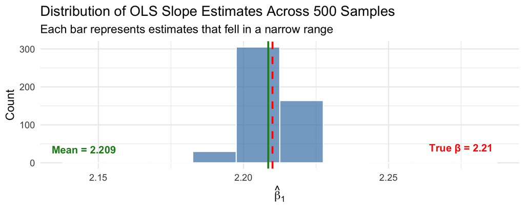

- Individual estimates vary, but the **average** equals the true value!

# So What? Bias, OVB, and Causality

## When Assumption 4 Fails

- When $E[\mu | x] \neq 0$, OLS is **biased** – and the most common reason is **omitted variable bias**
- If a variable that belongs in the model is left out AND is correlated with $x$, our slope picks up the effect of both
- Example: estimating the return to education while omitting ability → $\hat{\beta}_1$ **overstates** the causal effect
- Remember from Unit 3: this is essentially **selection bias** – people who choose more education also tend to have higher ability

## The Big Picture

- When $E[\mu | x] = 0$: $\hat{\beta}_1$ is an unbiased estimate of the **causal effect**
- When $E[\mu | x] \neq 0$: $\hat{\beta}_1$ measures **correlation**, not causation

**Correlation vs. Causation**

OLS always estimates *something*. Whether that something is a **causal effect** or merely a **correlation** depends entirely on whether the assumptions hold. Most of econometrics is about finding clever ways to make the zero conditional mean assumption more plausible.

**Coming Up Next**

**Multivariate regression** gives us the tools to **control for** confounding variables by adding more $x$’s to our model – directly addressing omitted variable bias.

# Variance, Standard Errors, and BLUE

## Beyond Unbiasedness

- Unbiasedness tells us OLS is “right on average” – but individual estimates can vary a lot
- We also care about **precision**: how much do estimates bounce around from sample to sample?
- This is measured by the **variance** of the estimator

## Assumption 5: Homoskedasticity

- To derive the variance of OLS, we need one more assumption:

$$Var(\mu | x) = \sigma^2$$

- The “spread” of errors is **constant** across all values of $x$

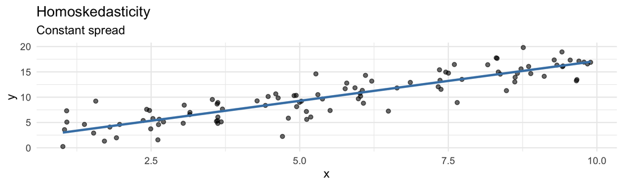

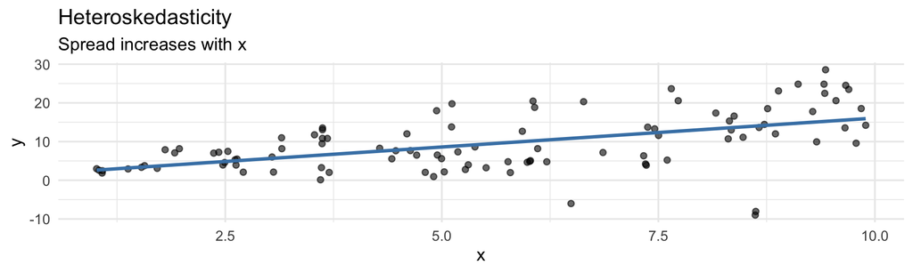

## Deriving the Variance of $\hat{\beta}_1$: Sketch

- Start from the slope formula. Using the fact that $y_i = \beta_0 + \beta_1 x_i + \mu_i$:

$$\hat{\beta}_1 = \beta_1 + \frac{\sum(x_i - \bar{x})\mu_i}{\sum(x_i - \bar{x})^2}$$

- The only random piece is $\mu_i$, so the variance comes from the second term:

$$Var(\hat{\beta}_1) = Var\left(\frac{\sum(x_i - \bar{x})\mu_i}{\sum(x_i - \bar{x})^2}\right)$$

## Deriving the Variance: Result

- Since $\sum(x_i - \bar{x})^2$ is a constant (fixed in our sample) and the $\mu_i$ are independent with constant variance $\sigma^2$:

$$Var(\hat{\beta}_1) = \frac{\sum(x_i - \bar{x})^2 \cdot \sigma^2}{\left[\sum(x_i - \bar{x})^2\right]^2} = \frac{\sigma^2}{\sum(x_i - \bar{x})^2}$$

**Variance of the OLS Slope**

$$Var(\hat{\beta}_1) = \frac{\sigma^2}{SST_x}$$

where $\sigma^2 = Var(\mu)$ is the error variance and $SST_x = \sum(x_i - \bar{x})^2$ is the total variation in $x$.

## What Affects Precision?

$$Var(\hat{\beta}_1) = \frac{\sigma^2}{SST_x}$$

Two key insights:

1. **More noise** ($\sigma^2$ ↑) → **less** precise estimates (wider distribution)
2. **More variation in $x$** ($SST_x$ ↑) → **more** precise estimates (tighter distribution)
- Let’s see this with simulations!

## Effect of Error Variance on Precision

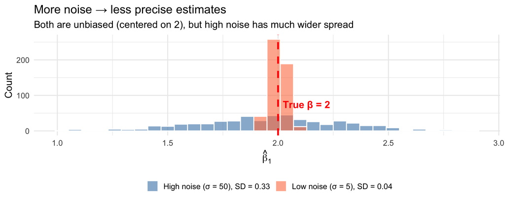

## Effect of Variation in $x$ on Precision

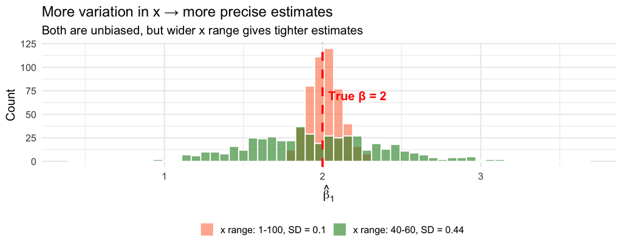

## Effect of Sample Size on Precision

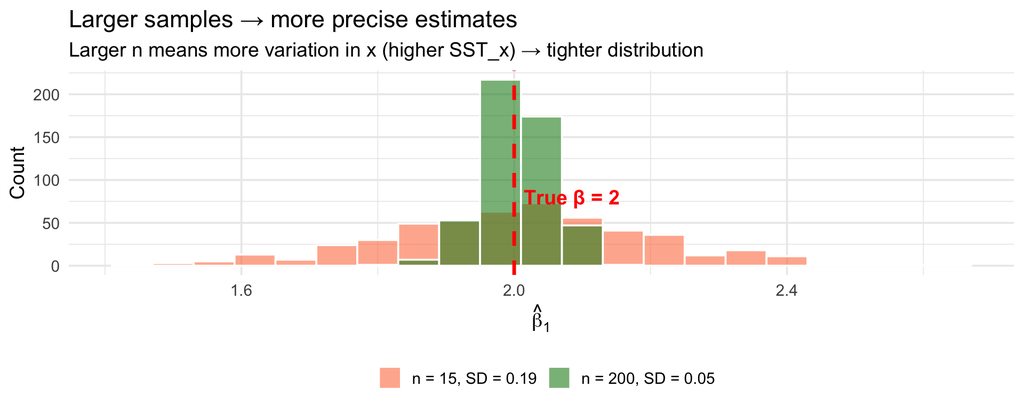

## Standard Errors

- The **standard error** is the estimated standard deviation of $\hat{\beta}_1$:

$$se(\hat{\beta}_1) = \sqrt{Var(\hat{\beta}_1)} = \frac{\hat{\sigma}}{\sqrt{SST_x}}$$

- where $\hat{\sigma}$ estimates the error standard deviation from the residuals
- Standard errors quantify the **precision** of our estimates
- They are essential for hypothesis testing and confidence intervals (next unit!)

## OLS is BLUE

Under all five Gauss-Markov assumptions, OLS is **BLUE**:

- **B**est: Lowest variance among all linear unbiased estimators
- **L**inear: A linear function of the data
- **U**nbiased: $E[\hat{\beta}] = \beta$
- **E**stimator: A rule for using sample data to estimate parameters
- You cannot do better without accepting some bias or using non-linear methods!

## Which Assumptions Matter for What?

| Assumption | Needed for Unbiasedness? | Needed for BLUE? |
| --- | --- | --- |
| 1. Linear in parameters | Yes | Yes |
| 2. Random sampling | Yes | Yes |
| 3. Variation in $x$ | Yes | Yes |
| **4. Zero conditional mean** | **Yes** | Yes |
| 5. Homoskedasticity | No | **Yes** |

- Assumptions 1-4 → OLS is **unbiased**
- All five → OLS is **BLUE** (Best Linear Unbiased Estimator)

# Practice Exercises

## Practice: Interpreting Regression Output

**🖥️ Your turn!**

**A researcher estimates the relationship between test scores and class size:**

```
             Estimate  Std. Error
(Intercept)   698.93      10.36
str            -2.28       0.52

n = 420, R-squared = 0.051
```

*(`str` = student-teacher ratio)*

**Questions:**

1. What happens to predicted scores with 5 more students per teacher?
2. What is the predicted score when `str = 20`?
3. What does the R-squared tell us?

## Practice: Answers

1. $5 \times (-2.28) = -11.4$ points lower
2. $698.93 + (-2.28)(20) = 698.93 - 45.6 = 653.33$
3. About 5.1% of the variation in test scores is explained by class size. This is low, but does NOT mean class size is unimportant – it just means other factors also matter.

## Practice: Run a Full Analysis

**🖥️ Your turn!**

Using `mtcars`, complete the following:

1. Create a scatter plot of `disp` (displacement) vs. `mpg` with a line of best fit
2. Run `lm(mpg ~ disp, data = mtcars)` and interpret the slope
3. What is the R-squared? What does it mean?

```r
ggplot(mtcars, aes(x = disp, y = mpg)) +
  geom_point(alpha = 0.6) +
  geom_smooth(method = "lm") +
  labs(x = "Displacement (cu.in.)", y = "MPG",
       title = "MPG vs. Engine Displacement") +
  theme_minimal()
```

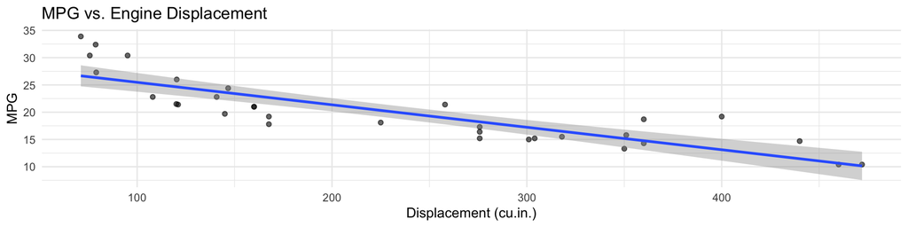

## Practice: Results

```r
summary(lm(mpg ~ disp, data = mtcars))
```

```
Call:
lm(formula = mpg ~ disp, data = mtcars)

Residuals:
    Min      1Q  Median      3Q     Max
-4.8922 -2.2022 -0.9631  1.6272  7.2305

Coefficients:
             Estimate Std. Error t value Pr(>|t|)
(Intercept) 29.599855   1.229720  24.070  < 2e-16 ***
disp        -0.041215   0.004712  -8.747 9.38e-10 ***
---
Signif. codes:  0 '***' 0.001 '**' 0.01 '*' 0.05 '.' 0.1 ' ' 1

Residual standard error: 3.251 on 30 degrees of freedom
Multiple R-squared:  0.7183,    Adjusted R-squared:  0.709
F-statistic: 76.51 on 1 and 30 DF,  p-value: 9.38e-10
```

## Practice: Identifying Assumption Violations

**🖥️ Your turn!**

**For each scenario, which Gauss-Markov assumption is most likely violated? Discuss with your neighbor!**

1. You study the effect of education on wages, but can’t observe ability
- *Assumption 4 (zero conditional mean): ability is in the error term and correlated with education*
2. You survey only college students about the effect of income on happiness
- *Assumption 2 (random sampling): your sample is not representative of the general population*

# Summary and Key Takeaways

## What We Learned

1. The **conditional expectation** $E[Y|X]$ is what we want to estimate
2. **Scatter plots** with `ggplot2` visualize relationships and regression lines
3. The **OLS slope** = $Cov(x,y)/Var(x)$ – essentially a scaled correlation
4. The **Gauss-Markov assumptions** (especially zero conditional mean) determine when OLS is unbiased
5. **Unbiasedness** means OLS hits the target on average; **precision** depends on noise and variation in $x$
6. **Causality requires unbiasedness** – only when $E[\mu|x] = 0$ can we interpret $\hat{\beta}_1$ causally

## The Key Equations

**The OLS Slope:**

$$\hat{\beta}_1 = \frac{Cov(x, y)}{Var(x)} = \frac{\sum(x_i - \bar{x})(y_i - \bar{y})}{\sum(x_i - \bar{x})^2}$$

**The OLS Intercept:**

$$\hat{\beta}_0 = \bar{y} - \hat{\beta}_1 \bar{x}$$

**The Variance of the Slope:**

$$Var(\hat{\beta}_1) = \frac{\sigma^2}{SST_x}$$

## Looking Ahead

- Next up: **Multivariate Regression** – adding more $x$ variables to address omitted variable bias
- Then: **Statistical Inference** – hypothesis testing, confidence intervals, and when we can say a result is “statistically significant”